# Diagramas causales

# Introducción

Los diagramas causales o **grafos** son representaciones gráficas de las relaciones entre causas y efectos. Con estas representaciones podemos ver más claramente cómo se relacionan los distintos factores que, por ejemplo, producen una enfermedad.

# Elementos de los grafos

Empecemos con la situación más sencilla, en la que una causa A y una enfermedad B pueden estar asociadas.

```r
g1 <- dagitty("dag {
  A
  B
               }")
plot( graphLayout( g1 ) )
```

[output not shown]

A esos dos elementos, **A** y **B** los llamamos *nodos*.  
Podemos relacionar los nodos mediante **enlaces**. Cada enlace une solamente dos nodos. Si planteamos que A es una *causa* de B, representamos la relación con un eje que los conecta.

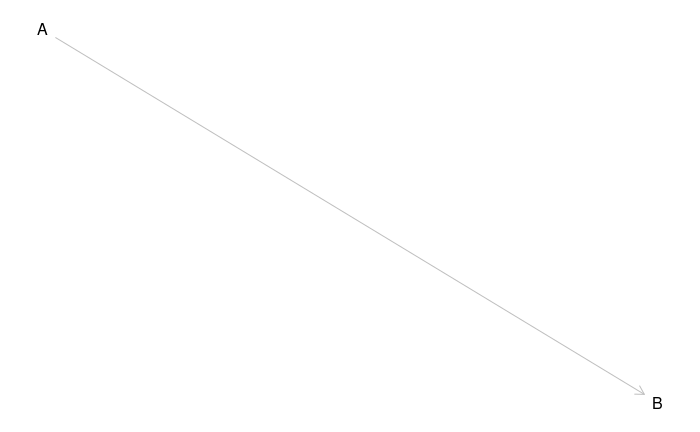

```r
g1 <- dagitty("dag {
  A -> B
               }")
plot( graphLayout( g1 ) )
```

Al nodo **A** lo llamamos *padre* o *predecesor*, y a **B**, *hijo* o *sucesor*. Ambos están conectados por un *eje*, que se dirige desde A hasta B. Por ello, lo llamamos *grafo dirigido*. Ese enlace es *dirigido*, porque va desde **A** hasta **B**. Si la relación fuera desde **B** hasta **A**, dibujaríamos un enlace diferente, desde B hasta A. Es decir, los enlaces forman relaciones ordenadas. Si la relación entre dos factores solamente puede ir en un único sentido, decimos que es un *grafo dirigido acíclico* (GDA). En este ejemplo, la relación entre A y B la representamos con un GDA.

# Relaciones

Supongamos que, en la aparición de una enfermedad, **C**, intervienen dos factores, **A** y **B**. Aquí podemos encontrarnos con varias situaciones:

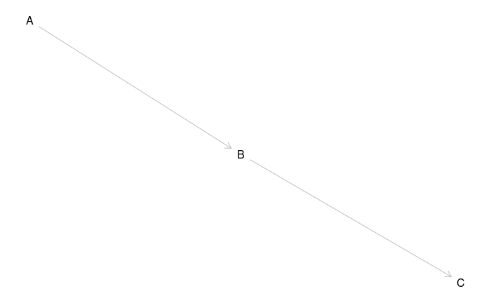

```r
g3 <- dagitty("dag {
  A -> B -> C
               }")
plot( graphLayout( g3 ) )
```

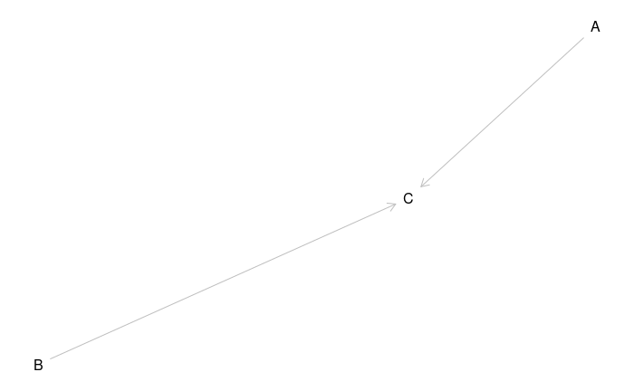

```r
g4 <- dagitty("dag {
  A -> C
  B -> C
               }")
plot( graphLayout( g4 ) )
```

Un *camino* está formado por una sucesión de nodos, de tal forma que entre dos de ellos consecutivos existe un enlace. En nuestro caso, solamente estudiaremos caminos *simples*; es decir, que no pasan dos veces por el mismo nodo.

Tanto **A** como **B** se comportan como causas suficientes, pero no necesarias. Por otro lado, a **C** lo llamamos un nodo *colisionador*, porque en ese punto “colisionan” los efectos tanto de **A** como de **B**.  
Hay otras situaciones que pueden presentarse. Veamos la primera.

```r
g5 <- dagitty("dag {
  A -> C
  A -> B
  B -> C
               }")
plot( graphLayout( g5 ) )
```

[output not shown]

Vemos que **A** interviene directamente sobre **C**, pero también lo hace indirectamente a través de **B**. Nos ocuparemos más adelante de este tipo de situaciones, porque dan lugar a un tipo de sesgo que llamamos de *confusión*.

Pasemos al siguiente grafo:

```r
g6 <- dagitty("dag {
  A <- C
  A -> B
  B -> C
               }")
plot( graphLayout( g6 ) )
```

[output not shown]

En este caso, los tres nodos están relacionados, pero el grafo es *cíclico*: cada nodo actúa como causa y también como efecto.